# 1. What Factors Sell a Car?

Hundreds of free vehicle ads and datasets are available on the websites such as kraggle.com every day. An analyst needs to study a collection of data over the past few years and determine the factors that influence the price of a vehicle.

The aim of this project is to find out how the following factors influence car selling prices in general:

1. Mileage
2. Age
3. Paint color
4. Transmission type

To be able to draw the conclusions above, the process stages in this project are:

1. Data pre-processing
2. Address missing values
3. Improve data type and quality
4. Study core parameters
5. Get rid of outliers and re-study the core parameters without outliers
6. Draw conclusions about how long advertisements are generally shown to determine the minimum length of advertisements as a consideration for involving data in the analysis.
7. Draw conclusions about the general price of each type of car
8. Analyze the relationship to car prices from the 4 factors that are the aim of this project

# 1.1. Pre-processing

Load the required libraries

# 2.1 Loading Data

# 2.2 Exploring Initial Data

The dataset contains the following columns:

- `price`
- `model_year`
- `model`
- `condition`
- `cylinders`
- `fuel` — gas, disel, dan lain-lain.
- `odometer` —vehicle mileage when the ad is shown
- `transmission`
- `paint_color`
- `is_4wd` —whether the vehicle has 4 wheel drive (Boolean type))
- `date_posted` —the date the ad was broadcast
- `days_listed` —number of days the ad is displayed until it is removeds

```
<class 'pandas.core.frame.DataFrame'>
RangeIndex: 51525 entries, 0 to 51524
Data columns (total 13 columns):
 #   Column        Non-Null Count  Dtype
---  ------        --------------  -----
 0   price         51525 non-null  int64
 1   model_year    47906 non-null  float64
 2   model         51525 non-null  object
 3   condition     51525 non-null  object
 4   cylinders     46265 non-null  float64
 5   fuel          51525 non-null  object
 6   odometer      43633 non-null  float64
 7   transmission  51525 non-null  object
 8   type          51525 non-null  object
 9   paint_color   42258 non-null  object
 10  is_4wd        25572 non-null  float64
 11  date_posted   51525 non-null  object
 12  days_listed   51525 non-null  int64
dtypes: float64(4), int64(2), object(7)
memory usage: 5.1+ MB
```

|  | price | model_year | model | condition | cylinders | fuel | odometer | transmission | type | paint_color | is_4wd | date_posted | days_listed |
| --- | --- | --- | --- | --- | --- | --- | --- | --- | --- | --- | --- | --- | --- |
| 0 | 9400 | 2011.0 | bmw x5 | good | 6.0 | gas | 145000.0 | automatic | SUV | NaN | 1.0 | 2018-06-23 | 19 |
| 1 | 25500 | NaN | ford f-150 | good | 6.0 | gas | 88705.0 | automatic | pickup | white | 1.0 | 2018-10-19 | 50 |
| 2 | 5500 | 2013.0 | hyundai sonata | like new | 4.0 | gas | 110000.0 | automatic | sedan | red | NaN | 2019-02-07 | 79 |
| 3 | 1500 | 2003.0 | ford f-150 | fair | 8.0 | gas | NaN | automatic | pickup | NaN | NaN | 2019-03-22 | 9 |
| 4 | 14900 | 2017.0 | chrysler 200 | excellent | 4.0 | gas | 80903.0 | automatic | sedan | black | NaN | 2019-04-02 | 28 |
| 5 | 14990 | 2014.0 | chrysler 300 | excellent | 6.0 | gas | 57954.0 | automatic | sedan | black | 1.0 | 2018-06-20 | 15 |
| 6 | 12990 | 2015.0 | toyota camry | excellent | 4.0 | gas | 79212.0 | automatic | sedan | white | NaN | 2018-12-27 | 73 |
| 7 | 15990 | 2013.0 | honda pilot | excellent | 6.0 | gas | 109473.0 | automatic | SUV | black | 1.0 | 2019-01-07 | 68 |
| 8 | 11500 | 2012.0 | kia sorento | excellent | 4.0 | gas | 104174.0 | automatic | SUV | NaN | 1.0 | 2018-07-16 | 19 |
| 9 | 9200 | 2008.0 | honda pilot | excellent | NaN | gas | 147191.0 | automatic | SUV | blue | 1.0 | 2019-02-15 | 17 |

|  | price | model_year | cylinders | odometer | is_4wd | days_listed |
| --- | --- | --- | --- | --- | --- | --- |
| count | 51525.000000 | 47906.000000 | 46265.000000 | 43633.000000 | 25572.0 | 51525.00000 |
| mean | 12132.464920 | 2009.750470 | 6.125235 | 115553.461738 | 1.0 | 39.55476 |
| std | 10040.803015 | 6.282065 | 1.660360 | 65094.611341 | 0.0 | 28.20427 |
| min | 1.000000 | 1908.000000 | 3.000000 | 0.000000 | 1.0 | 0.00000 |
| 25% | 5000.000000 | 2006.000000 | 4.000000 | 70000.000000 | 1.0 | 19.00000 |
| 50% | 9000.000000 | 2011.000000 | 6.000000 | 113000.000000 | 1.0 | 33.00000 |
| 75% | 16839.000000 | 2014.000000 | 8.000000 | 155000.000000 | 1.0 | 53.00000 |
| max | 375000.000000 | 2019.000000 | 12.000000 | 990000.000000 | 1.0 | 271.00000 |

```
price
1        798
6995     719
5995     655
4995     624
3500     620
        ...
58500      1
3993       1
32987      1
3744       1
7455       1
Name: count, Length: 3443, dtype: int64
model_year
NaN       3619
2013.0    3549
2012.0    3468
2014.0    3448
2011.0    3375
          ...
1948.0       1
1961.0       1
1936.0       1
1949.0       1
1929.0       1
Name: count, Length: 69, dtype: int64
model
ford f-150                           2796
chevrolet silverado 1500             2171
ram 1500                             1750
chevrolet silverado                  1271
jeep wrangler                        1119
                                     ...
ford f-250 super duty                 241
acura tl                              236
kia sorento                           236
nissan murano                         235
mercedes-benz benze sprinter 2500      41
Name: count, Length: 100, dtype: int64
condition
```

[output cut: 87 more lines]

```
2019-01-04    116
Name: count, Length: 354, dtype: int64
days_listed
18     959
24     950
22     945
19     941
20     934
      ...
240      1
209      1
188      1
192      1
186      1
Name: count, Length: 227, dtype: int64
```

```
0
```

From the info it looks like a lot of value is missing. Some data types do not match the values, namely in the is_4wd, cylinders, model_year, and date_posted columns.

The data type for the question whether the vehicle is *four-wheel drives* should be boolean. Year and number of cylinders should also be integers. And the date should be datetime.

```
price               0
model_year       3619
model               0
condition           0
cylinders        5260
fuel                0
odometer         7892
transmission        0
type                0
paint_color      9267
is_4wd          25953
date_posted         0
days_listed         0
dtype: int64
```

Missing values are in 5 columns: model_year, cylinders, is_4wd, odometer, and paint_color. The most common column is is_4wd. This means about 50% of the total rows.

# 5.1

Addressing Lost Values

```
model_year
NaN       0.070238
2013.0    0.068879
2012.0    0.067307
2014.0    0.066919
2011.0    0.065502
2015.0    0.064493
2016.0    0.057331
2008.0    0.056749
2010.0    0.052227
2007.0    0.051295
Name: proportion, dtype: float64
```

```
model
acura tl             2007.0
bmw x5               2010.0
buick enclave        2012.0
cadillac escalade    2009.0
chevrolet camaro     2013.0
                      ...
toyota sienna        2008.0
toyota tacoma        2010.0
toyota tundra        2009.0
volkswagen jetta     2012.0
volkswagen passat    2013.0
Name: model_year, Length: 100, dtype: float64
```

```
<class 'pandas.core.frame.DataFrame'>
RangeIndex: 51525 entries, 0 to 51524
Data columns (total 13 columns):
 #   Column        Non-Null Count  Dtype
---  ------        --------------  -----
 0   price         51525 non-null  int64
 1   model_year    51525 non-null  float64
 2   model         51525 non-null  object
 3   condition     51525 non-null  object
 4   cylinders     46265 non-null  float64
 5   fuel          51525 non-null  object
 6   odometer      43633 non-null  float64
 7   transmission  51525 non-null  object
 8   type          51525 non-null  object
 9   paint_color   42258 non-null  object
 10  is_4wd        51525 non-null  float64
 11  date_posted   51525 non-null  object
 12  days_listed   51525 non-null  int64
dtypes: float64(4), int64(2), object(7)
memory usage: 5.1+ MB
```

```
count    51525.000000
mean      2009.793954
std          6.099296
min       1908.000000
25%       2007.000000
50%       2011.000000
75%       2014.000000
max       2019.000000
Name: model_year, dtype: float64
```

It can be seen that the distribution of values in model_year has not changed significantly. Missing values have been filled in but the distribution is not affected much. This is because the typical value used is the median per model group.

Next let's handle the missing values of the `odometer` column.

```
count     43633.000000
mean     115553.461738
std       65094.611341
min           0.000000
25%       70000.000000
50%      113000.000000
75%      155000.000000
max      990000.000000
Name: odometer, dtype: float64
```

```
count     51525.000000
mean     115199.014508
std       60484.863376
min           0.000000
25%       75668.000000
50%      110908.000000
75%      147821.000000
max      990000.000000
Name: odometer, dtype: float64
```

Next let's handle the missing values of the `cylinders` column.

In the `cylinders` column, the portion of values missing is 10%. Every car must have a cylinder. From the available data, the factor most related to cylinders is `model`. Therefore, missing values will be filled using typical data based on `model`. The median will be used as a substitute for missing values because the data form is discrete.

```
cylinders
8.0     0.307501
6.0     0.304706
4.0     0.269073
NaN     0.102086
10.0    0.010655
5.0     0.005279
3.0     0.000660
12.0    0.000039
Name: proportion, dtype: float64
```

To decide to fill in the missing values for `cylinders`, let's see whether a certain number of cylinders dominates each existing model, namely by looking at the distribution of cylinder values in several sample models.

```
model
ford f-150                  316
chevrolet silverado 1500    231
ram 1500                    185
Name: count, dtype: int64
```

```
cylinders
8.0     1584
6.0      863
10.0      18
4.0       11
3.0        2
5.0        2
Name: count, dtype: int64
```

```
cylinders
8.0     1714
6.0      219
4.0        4
10.0       3
Name: count, dtype: int64
```

```
cylinders
8.0     1348
6.0      199
10.0      17
4.0        1
Name: count, dtype: int64
```

From the 3 samples it was found that the model had a certain number of cylinders that dominated. Therefore, the median number of cylinders according to the model will be used to fill in the missing values for cylinders. At the same time not to shift the overall data distribution too much.

```
cylinders
8.0     0.343755
6.0     0.338379
4.0     0.300805
10.0    0.010655
5.0     0.005706
3.0     0.000660
12.0    0.000039
Name: proportion, dtype: float64
```

It can be seen that the distribution of values in the cylinders has not changed significantly. Missing values have been filled in but the distribution is not affected much. This is because the typical value used is the median per model group.

Next let's handle missing values in `paint_color`. The color of the car cannot be related to the model or other factors. And this factor will be analyzed for its influence on prices. In order not to disrupt data distribution, `unknown` will be used to fill in missing values.

```
paint_color
white     10029
NaN        9267
black      7692
silver     6244
grey       5037
blue       4475
red        4421
green      1396
brown      1223
custom     1153
yellow      255
orange      231
purple      102
Name: count, dtype: int64
```

```
price           0
model_year      0
model           0
condition       0
cylinders       0
fuel            0
odometer        0
transmission    0
type            0
paint_color     0
is_4wd          0
date_posted     0
days_listed     0
dtype: int64
```

## 6.0 Fixed Data Type

The data is complete, it's time to correct the data type.

```
<class 'pandas.core.frame.DataFrame'>
RangeIndex: 51525 entries, 0 to 51524
Data columns (total 13 columns):
 #   Column        Non-Null Count  Dtype
---  ------        --------------  -----
 0   price         51525 non-null  int64
 1   model_year    51525 non-null  int32
 2   model         51525 non-null  object
 3   condition     51525 non-null  object
 4   cylinders     51525 non-null  int32
 5   fuel          51525 non-null  object
 6   odometer      51525 non-null  float64
 7   transmission  51525 non-null  object
 8   type          51525 non-null  object
 9   paint_color   51525 non-null  object
 10  is_4wd        51525 non-null  bool
 11  date_posted   51525 non-null  datetime64[ns]
 12  days_listed   51525 non-null  int64
dtypes: bool(1), datetime64[ns](1), float64(1), int32(2), int64(2), object(6)
memory usage: 4.4+ MB
```

Missing values have been handled and data types have been adjusted for each column required for EDA and feature engineering for further analysis.

## 6.2 Improving Data Quality

The data will be added with other necessary factors to make it easier to analyze.

|  | price | model_year | model | condition | cylinders | fuel | odometer | transmission | type | paint_color | is_4wd | date_posted | days_listed |
| --- | --- | --- | --- | --- | --- | --- | --- | --- | --- | --- | --- | --- | --- |
| 0 | 9400 | 2011 | bmw x5 | good | 6 | gas | 145000.0 | automatic | SUV | unknown | True | 2018-06-23 | 19 |
| 1 | 25500 | 2011 | ford f-150 | good | 6 | gas | 88705.0 | automatic | pickup | white | True | 2018-10-19 | 50 |
| 2 | 5500 | 2013 | hyundai sonata | like new | 4 | gas | 110000.0 | automatic | sedan | red | False | 2019-02-07 | 79 |
| 3 | 1500 | 2003 | ford f-150 | fair | 8 | gas | 181613.0 | automatic | pickup | unknown | False | 2019-03-22 | 9 |
| 4 | 14900 | 2017 | chrysler 200 | excellent | 4 | gas | 80903.0 | automatic | sedan | black | False | 2019-04-02 | 28 |

```
condition
3    24773
2    20145
4     4742
1     1607
5      143
0      115
Name: count, dtype: int64
```

## 6.3 Checking Clean Data

now time to check the clean data

```
<class 'pandas.core.frame.DataFrame'>
RangeIndex: 51525 entries, 0 to 51524
Data columns (total 20 columns):
 #   Column             Non-Null Count  Dtype
---  ------             --------------  -----
 0   price              51525 non-null  int64
 1   model_year         51525 non-null  int32
 2   model              51525 non-null  object
 3   condition          51525 non-null  int64
 4   cylinders          51525 non-null  int32
 5   fuel               51525 non-null  object
 6   odometer           51525 non-null  float64
 7   transmission       51525 non-null  object
 8   type               51525 non-null  object
 9   paint_color        51525 non-null  object
 10  is_4wd             51525 non-null  bool
 11  date_posted        51525 non-null  datetime64[ns]
 12  days_listed        51525 non-null  int64
 13  day_name_posted    51525 non-null  object
 14  day_posted         51525 non-null  int32
 15  month_posted       51525 non-null  int32
 16  month_name_posted  51525 non-null  object
 17  year_posted        51525 non-null  int32
 18  age                51525 non-null  int32
 19  odometer_annual    51525 non-null  float64
dtypes: bool(1), datetime64[ns](1), float64(2), int32(6), int64(3), object(7)
memory usage: 6.3+ MB
```

|  | price | model_year | model | condition | cylinders | fuel | odometer | transmission | type | paint_color | is_4wd | date_posted | days_listed | day_name_posted | day_posted | month_posted | month_name_posted | year_posted | age | odometer_annual |
| --- | --- | --- | --- | --- | --- | --- | --- | --- | --- | --- | --- | --- | --- | --- | --- | --- | --- | --- | --- | --- |
| 0 | 9400 | 2011 | bmw x5 | 2 | 6 | gas | 145000.0 | automatic | SUV | unknown | True | 2018-06-23 | 19 | Saturday | 23 | 6 | June | 2018 | 7 | 20714.285714 |
| 1 | 25500 | 2011 | ford f-150 | 2 | 6 | gas | 88705.0 | automatic | pickup | white | True | 2018-10-19 | 50 | Friday | 19 | 10 | October | 2018 | 7 | 12672.142857 |
| 2 | 5500 | 2013 | hyundai sonata | 4 | 4 | gas | 110000.0 | automatic | sedan | red | False | 2019-02-07 | 79 | Thursday | 7 | 2 | February | 2019 | 6 | 18333.333333 |
| 3 | 1500 | 2003 | ford f-150 | 1 | 8 | gas | 181613.0 | automatic | pickup | unknown | False | 2019-03-22 | 9 | Friday | 22 | 3 | March | 2019 | 16 | 11350.812500 |
| 4 | 14900 | 2017 | chrysler 200 | 3 | 4 | gas | 80903.0 | automatic | sedan | black | False | 2019-04-02 | 28 | Tuesday | 2 | 4 | April | 2019 | 2 | 40451.500000 |

## 6.4 Studying Core Parameters

The parameters to be studied are:

- Price
- Vehicle age when the ad is displayed
- Mileage
- Number of cylinders
- Condition

For numerical ratio parameters, namely: price, age, odometer, histogram will be used.

Meanwhile, for ordinal categorical parameters, namely: cylinders, condition, countplot will be used.

And to check for the presence of outliers, a boxplot will be used to depict the distribution in each parameter.

Functions will be defined so that coding does not need to be written repeatedly.

|  | price | model_year | condition | cylinders | odometer | date_posted | days_listed | day_posted | month_posted | year_posted | age | odometer_annual |
| --- | --- | --- | --- | --- | --- | --- | --- | --- | --- | --- | --- | --- |
| count | 51525.000000 | 51525.000000 | 51525.000000 | 51525.000000 | 51525.000000 | 51525 | 51525.00000 | 51525.000000 | 51525.000000 | 51525.000000 | 51525.000000 | 51525.000000 |
| mean | 12132.464920 | 2009.793557 | 2.637535 | 6.121067 | 115199.014508 | 2018-10-25 01:57:46.270742528 | 39.55476 | 15.449491 | 6.628491 | 2018.307462 | 8.555672 | 18930.822069 |
| min | 1.000000 | 1908.000000 | 0.000000 | 3.000000 | 0.000000 | 2018-05-01 00:00:00 | 0.00000 | 1.000000 | 1.000000 | 2018.000000 | 1.000000 | 0.000000 |
| 25% | 5000.000000 | 2007.000000 | 2.000000 | 4.000000 | 75668.000000 | 2018-07-29 00:00:00 | 19.00000 | 8.000000 | 3.000000 | 2018.000000 | 4.000000 | 10423.000000 |
| 50% | 9000.000000 | 2011.000000 | 3.000000 | 6.000000 | 110908.000000 | 2018-10-25 00:00:00 | 33.00000 | 15.000000 | 7.000000 | 2018.000000 | 8.000000 | 14982.500000 |
| 75% | 16839.000000 | 2014.000000 | 3.000000 | 8.000000 | 147821.000000 | 2019-01-21 00:00:00 | 53.00000 | 23.000000 | 10.000000 | 2019.000000 | 12.000000 | 21800.000000 |
| max | 375000.000000 | 2019.000000 | 5.000000 | 12.000000 | 990000.000000 | 2019-04-19 00:00:00 | 271.00000 | 31.000000 | 12.000000 | 2019.000000 | 110.000000 | 373200.000000 |
| std | 10040.803015 | 6.099381 | 0.712447 | 1.657457 | 60484.863376 | NaN | 28.20427 | 8.736521 | 3.474134 | 0.461447 | 6.057829 | 16268.514686 |

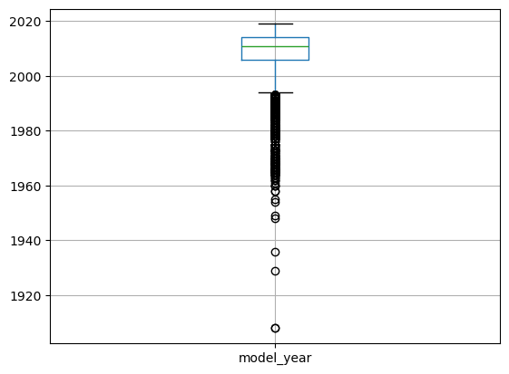

[figure not shown]

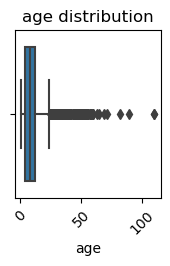

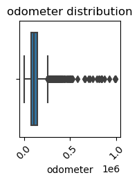

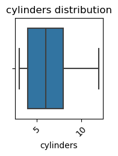

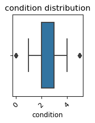

[figure not shown]

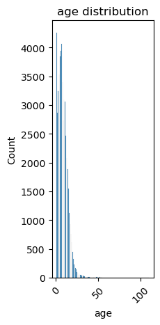

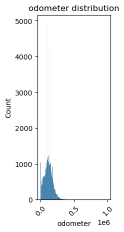

[figure not shown]

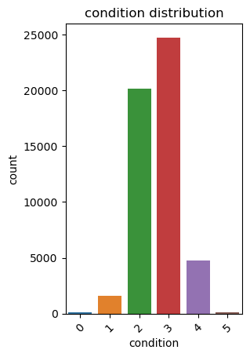

## 6.5 Studying and Handling Outliers

From the graph above, it can be seen that the price, age, and odometer columns have outliers. While Cylinders do not.

The next step is defining outliers and filtering them from the data.

|  | price | model_year | condition | cylinders | odometer | date_posted | days_listed | day_posted | month_posted | year_posted | age | odometer_annual |
| --- | --- | --- | --- | --- | --- | --- | --- | --- | --- | --- | --- | --- |
| count | 47911.000000 | 47911.000000 | 47911.000000 | 47911.000000 | 47911.000000 | 47911 | 47911.000000 | 47911.000000 | 47911.000000 | 47911.000000 | 47911.000000 | 47911.000000 |
| mean | 11273.531047 | 2010.141095 | 2.639060 | 6.051011 | 113819.105080 | 2018-10-24 21:18:16.207551488 | 39.539250 | 15.454843 | 6.632694 | 2018.306568 | 8.198451 | 18798.411014 |
| min | 1.000000 | 1995.000000 | 0.000000 | 3.000000 | 1.000000 | 2018-05-01 00:00:00 | 0.000000 | 1.000000 | 1.000000 | 2018.000000 | 1.000000 | 0.052632 |
| 25% | 5000.000000 | 2007.000000 | 2.000000 | 4.000000 | 79000.000000 | 2018-07-29 00:00:00 | 19.000000 | 8.000000 | 3.000000 | 2018.000000 | 4.000000 | 10596.750000 |
| 50% | 8995.000000 | 2011.000000 | 3.000000 | 6.000000 | 112000.000000 | 2018-10-24 00:00:00 | 33.000000 | 15.000000 | 7.000000 | 2018.000000 | 7.000000 | 14928.461538 |
| 75% | 15995.000000 | 2014.000000 | 3.000000 | 8.000000 | 146000.000000 | 2019-01-21 00:00:00 | 53.000000 | 23.000000 | 10.000000 | 2019.000000 | 11.000000 | 21584.125000 |
| max | 34595.000000 | 2019.000000 | 5.000000 | 12.000000 | 253000.000000 | 2019-04-19 00:00:00 | 271.000000 | 31.000000 | 12.000000 | 2019.000000 | 23.000000 | 195700.000000 |
| std | 7836.391772 | 4.965727 | 0.697721 | 1.656933 | 52531.716484 | NaN | 28.207371 | 8.740585 | 3.472197 | 0.461073 | 4.927496 | 15395.192234 |

## 6.6

Studying Core Parameters Without Outliers

With the data cleaned of outliers, a histogram, countplot, and boxplot will be created.

|  | price | model_year | condition | cylinders | odometer | date_posted | days_listed | day_posted | month_posted | year_posted | age | odometer_annual |
| --- | --- | --- | --- | --- | --- | --- | --- | --- | --- | --- | --- | --- |
| count | 51525.000000 | 51525.000000 | 51525.000000 | 51525.000000 | 51525.000000 | 51525 | 51525.00000 | 51525.000000 | 51525.000000 | 51525.000000 | 51525.000000 | 51525.000000 |
| mean | 12132.464920 | 2009.793557 | 2.637535 | 6.121067 | 115199.014508 | 2018-10-25 01:57:46.270742528 | 39.55476 | 15.449491 | 6.628491 | 2018.307462 | 8.555672 | 18930.822069 |
| min | 1.000000 | 1908.000000 | 0.000000 | 3.000000 | 0.000000 | 2018-05-01 00:00:00 | 0.00000 | 1.000000 | 1.000000 | 2018.000000 | 1.000000 | 0.000000 |
| 25% | 5000.000000 | 2007.000000 | 2.000000 | 4.000000 | 75668.000000 | 2018-07-29 00:00:00 | 19.00000 | 8.000000 | 3.000000 | 2018.000000 | 4.000000 | 10423.000000 |
| 50% | 9000.000000 | 2011.000000 | 3.000000 | 6.000000 | 110908.000000 | 2018-10-25 00:00:00 | 33.00000 | 15.000000 | 7.000000 | 2018.000000 | 8.000000 | 14982.500000 |
| 75% | 16839.000000 | 2014.000000 | 3.000000 | 8.000000 | 147821.000000 | 2019-01-21 00:00:00 | 53.00000 | 23.000000 | 10.000000 | 2019.000000 | 12.000000 | 21800.000000 |
| max | 375000.000000 | 2019.000000 | 5.000000 | 12.000000 | 990000.000000 | 2019-04-19 00:00:00 | 271.00000 | 31.000000 | 12.000000 | 2019.000000 | 110.000000 | 373200.000000 |
| std | 10040.803015 | 6.099381 | 0.712447 | 1.657457 | 60484.863376 | NaN | 28.20427 | 8.736521 | 3.474134 | 0.461447 | 6.057829 | 16268.514686 |

|  | price | model_year | condition | cylinders | odometer | date_posted | days_listed | day_posted | month_posted | year_posted | age | odometer_annual |
| --- | --- | --- | --- | --- | --- | --- | --- | --- | --- | --- | --- | --- |
| count | 47911.000000 | 47911.000000 | 47911.000000 | 47911.000000 | 47911.000000 | 47911 | 47911.000000 | 47911.000000 | 47911.000000 | 47911.000000 | 47911.000000 | 47911.000000 |
| mean | 11273.531047 | 2010.141095 | 2.639060 | 6.051011 | 113819.105080 | 2018-10-24 21:18:16.207551488 | 39.539250 | 15.454843 | 6.632694 | 2018.306568 | 8.198451 | 18798.411014 |
| min | 1.000000 | 1995.000000 | 0.000000 | 3.000000 | 1.000000 | 2018-05-01 00:00:00 | 0.000000 | 1.000000 | 1.000000 | 2018.000000 | 1.000000 | 0.052632 |
| 25% | 5000.000000 | 2007.000000 | 2.000000 | 4.000000 | 79000.000000 | 2018-07-29 00:00:00 | 19.000000 | 8.000000 | 3.000000 | 2018.000000 | 4.000000 | 10596.750000 |
| 50% | 8995.000000 | 2011.000000 | 3.000000 | 6.000000 | 112000.000000 | 2018-10-24 00:00:00 | 33.000000 | 15.000000 | 7.000000 | 2018.000000 | 7.000000 | 14928.461538 |
| 75% | 15995.000000 | 2014.000000 | 3.000000 | 8.000000 | 146000.000000 | 2019-01-21 00:00:00 | 53.000000 | 23.000000 | 10.000000 | 2019.000000 | 11.000000 | 21584.125000 |
| max | 34595.000000 | 2019.000000 | 5.000000 | 12.000000 | 253000.000000 | 2019-04-19 00:00:00 | 271.000000 | 31.000000 | 12.000000 | 2019.000000 | 23.000000 | 195700.000000 |
| std | 7836.391772 | 4.965727 | 0.697721 | 1.656933 | 52531.716484 | NaN | 28.207371 | 8.740585 | 3.472197 | 0.461073 | 4.927496 | 15395.192234 |

```
<class 'pandas.core.frame.DataFrame'>
Index: 47911 entries, 0 to 51524
Data columns (total 20 columns):
 #   Column             Non-Null Count  Dtype
---  ------             --------------  -----
 0   price              47911 non-null  int64
 1   model_year         47911 non-null  int32
 2   model              47911 non-null  object
 3   condition          47911 non-null  int64
 4   cylinders          47911 non-null  int32
 5   fuel               47911 non-null  object
 6   odometer           47911 non-null  float64
 7   transmission       47911 non-null  object
 8   type               47911 non-null  object
 9   paint_color        47911 non-null  object
 10  is_4wd             47911 non-null  bool
 11  date_posted        47911 non-null  datetime64[ns]
 12  days_listed        47911 non-null  int64
 13  day_name_posted    47911 non-null  object
 14  day_posted         47911 non-null  int32
 15  month_posted       47911 non-null  int32
 16  month_name_posted  47911 non-null  object
 17  year_posted        47911 non-null  int32
 18  age                47911 non-null  int32
 19  odometer_annual    47911 non-null  float64
dtypes: bool(1), datetime64[ns](1), float64(2), int32(6), int64(3), object(7)
memory usage: 6.3+ MB
```

[figure not shown]

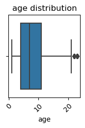

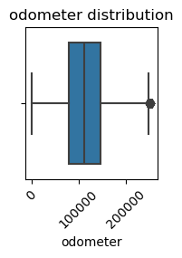

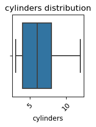

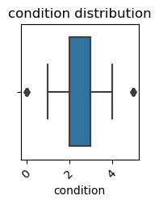

[figure not shown]

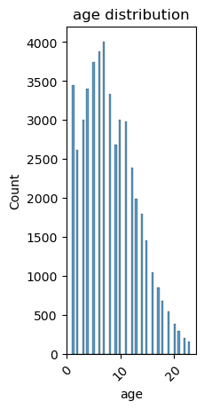

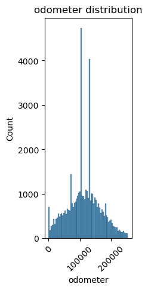

[figure not shown]

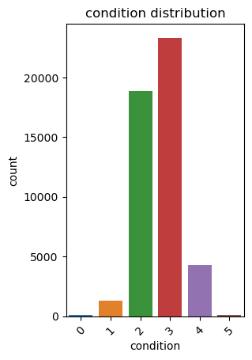

After filtering outliers on the price, age, and odometer parameters, the amount and distribution of data changes. The mean, median, Q1 and Q3 have shifted.

From the boxplot, it can be seen that the price, age and odometer parameters now have fewer outliers.

## 6.7 Ad Validity Time

Next, learn how many days ads are generally displayed (`days_listed`)

```
count    47911.000000
mean        39.539250
std         28.207371
min          0.000000
25%         19.000000
50%         33.000000
75%         53.000000
max        271.000000
Name: days_listed, dtype: float64
```

Generally ads run for around 33 to 40 days. Ads go down as soon as the same day they are aired, and as late as 271 days.

## 6.8 Average Price of Each Type of Vehicle

Next, analyze the number of advertisements and the average price for each type of vehicle. A graph showing the dependence of the number of advertisements on the type of vehicle will be created.

| type | model | price |
| --- | --- | --- |
| SUV | 11823 | 10487.598410 |
| bus | 21 | 18107.428571 |
| convertible | 341 | 13046.598240 |
| coupe | 2004 | 13565.540419 |
| hatchback | 1000 | 6828.041000 |
| mini-van | 1141 | 8072.185802 |
| offroad | 182 | 14344.049451 |
| other | 229 | 10602.698690 |
| pickup | 6221 | 15155.138724 |
| sedan | 11922 | 6987.910753 |
| truck | 10978 | 15216.104573 |
| van | 575 | 8892.730435 |
| wagon | 1474 | 9019.019674 |

[output not shown]

[output not shown]

```
([0, 1, 2, 3, 4, 5, 6, 7, 8, 9, 10, 11, 12],
 [Text(0, 0, 'bus'),
```

```
(array([ 0,  1,  2,  3,  4,  5,  6,  7,  8,  9, 10, 11, 12]),
 [Text(0, 0, '0'),
```

The most frequently advertised vehicle types are sedans and SUVs. The least is buses.

## 6.9 Price Factor

This stage will be analyzed to answer the factors that most influence vehicle prices.

The two most popular types of vehicles found in the previous stage will be studied. Test to see if price depends on:

1. Age
2. Mileage
3. Condition
4. Transmission type
5. Color.

Graphs will be created, namely *boxplot* for categorical variables (transmission type and color), and *scatterplot* for the rest.

Correlation matrix and correlation plot. First, EDA was carried out for the sedan type

|  | price | model_year | model | condition | cylinders | fuel | odometer | transmission | type | paint_color | is_4wd | date_posted | days_listed | day_name_posted | day_posted | month_posted | month_name_posted | year_posted | age | odometer_annual |
| --- | --- | --- | --- | --- | --- | --- | --- | --- | --- | --- | --- | --- | --- | --- | --- | --- | --- | --- | --- | --- |
| 0 | 5500 | 2013 | hyundai sonata | 4 | 4 | gas | 110000.0 | automatic | sedan | red | False | 2019-02-07 | 79 | Thursday | 7 | 2 | February | 2019 | 6 | 18333.333333 |
| 1 | 14900 | 2017 | chrysler 200 | 3 | 4 | gas | 80903.0 | automatic | sedan | black | False | 2019-04-02 | 28 | Tuesday | 2 | 4 | April | 2019 | 2 | 40451.500000 |
| 2 | 14990 | 2014 | chrysler 300 | 3 | 6 | gas | 57954.0 | automatic | sedan | black | True | 2018-06-20 | 15 | Wednesday | 20 | 6 | June | 2018 | 4 | 14488.500000 |
| 3 | 12990 | 2015 | toyota camry | 3 | 4 | gas | 79212.0 | automatic | sedan | white | False | 2018-12-27 | 73 | Thursday | 27 | 12 | December | 2018 | 3 | 26404.000000 |
| 4 | 8990 | 2012 | honda accord | 3 | 4 | gas | 111142.0 | automatic | sedan | grey | False | 2019-03-28 | 29 | Thursday | 28 | 3 | March | 2019 | 7 | 15877.428571 |

```
price              1.000000
model_year         0.617299
condition          0.291461
cylinders         -0.045236
odometer          -0.523802
days_listed        0.001278
day_posted         0.005391
month_posted      -0.017951
year_posted        0.015632
age               -0.611641
odometer_annual    0.306564
Name: price, dtype: float64
```

[figure not shown]

[figure not shown]

[figure not shown]

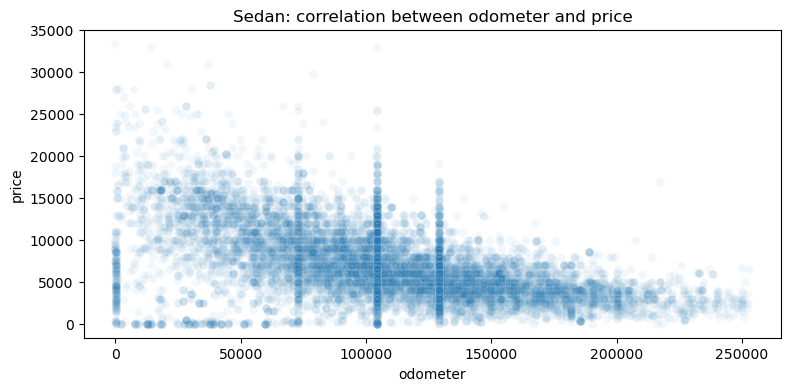

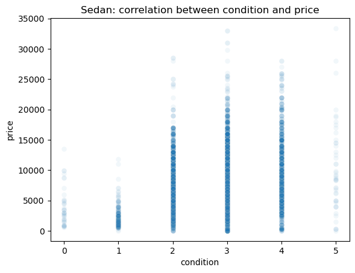

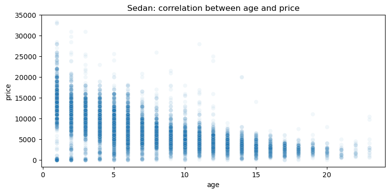

```
transmission
automatic    11221
manual         573
other          128
Name: count, dtype: int64
```

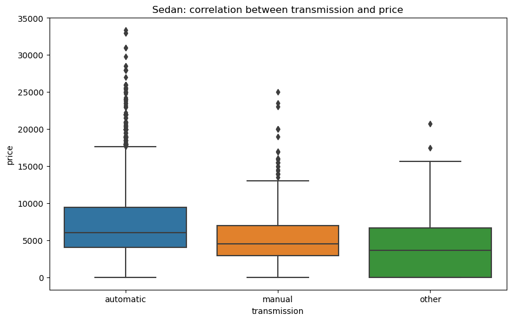

```
paint_color
unknown    2147
silver     2021
black      1746
grey       1603
white      1477
blue       1209
red         926
custom      292
brown       251
green       197
purple       23
yellow       21
orange        9
Name: count, dtype: int64
```

```
['unknown',
 'silver',
 'black',
 'grey',
 'white',
 'blue',
 'red',
 'custom',
 'brown',
 'green',
 'purple',
 'yellow',
 'orange']
```

|  | price | model_year | model | condition | cylinders | fuel | odometer | transmission | type | paint_color | is_4wd | date_posted | days_listed | day_name_posted | day_posted | month_posted | month_name_posted | year_posted | age | odometer_annual |
| --- | --- | --- | --- | --- | --- | --- | --- | --- | --- | --- | --- | --- | --- | --- | --- | --- | --- | --- | --- | --- |
| 0 | 5500 | 2013 | hyundai sonata | 4 | 4 | gas | 110000.0 | automatic | sedan | red | False | 2019-02-07 | 79 | Thursday | 7 | 2 | February | 2019 | 6 | 18333.333333 |
| 1 | 14900 | 2017 | chrysler 200 | 3 | 4 | gas | 80903.0 | automatic | sedan | black | False | 2019-04-02 | 28 | Tuesday | 2 | 4 | April | 2019 | 2 | 40451.500000 |
| 2 | 14990 | 2014 | chrysler 300 | 3 | 6 | gas | 57954.0 | automatic | sedan | black | True | 2018-06-20 | 15 | Wednesday | 20 | 6 | June | 2018 | 4 | 14488.500000 |
| 3 | 12990 | 2015 | toyota camry | 3 | 4 | gas | 79212.0 | automatic | sedan | white | False | 2018-12-27 | 73 | Thursday | 27 | 12 | December | 2018 | 3 | 26404.000000 |
| 4 | 8990 | 2012 | honda accord | 3 | 4 | gas | 111142.0 | automatic | sedan | grey | False | 2019-03-28 | 29 | Thursday | 28 | 3 | March | 2019 | 7 | 15877.428571 |

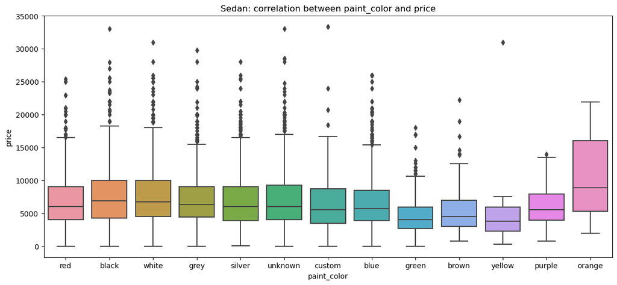

Next, EDA is carried out for the SUV type

|  | price | model_year | model | condition | cylinders | fuel | odometer | transmission | type | paint_color | is_4wd | date_posted | days_listed | day_name_posted | day_posted | month_posted | month_name_posted | year_posted | age | odometer_annual |
| --- | --- | --- | --- | --- | --- | --- | --- | --- | --- | --- | --- | --- | --- | --- | --- | --- | --- | --- | --- | --- |
| 0 | 9400 | 2011 | bmw x5 | 2 | 6 | gas | 145000.0 | automatic | SUV | unknown | True | 2018-06-23 | 19 | Saturday | 23 | 6 | June | 2018 | 7 | 20714.285714 |
| 1 | 15990 | 2013 | honda pilot | 3 | 6 | gas | 109473.0 | automatic | SUV | black | True | 2019-01-07 | 68 | Monday | 7 | 1 | January | 2019 | 6 | 18245.500000 |
| 2 | 11500 | 2012 | kia sorento | 3 | 4 | gas | 104174.0 | automatic | SUV | unknown | True | 2018-07-16 | 19 | Monday | 16 | 7 | July | 2018 | 6 | 17362.333333 |
| 3 | 9200 | 2008 | honda pilot | 3 | 6 | gas | 147191.0 | automatic | SUV | blue | True | 2019-02-15 | 17 | Friday | 15 | 2 | February | 2019 | 11 | 13381.000000 |
| 4 | 12990 | 2009 | gmc yukon | 3 | 8 | gas | 132285.0 | automatic | SUV | black | True | 2019-01-31 | 24 | Thursday | 31 | 1 | January | 2019 | 10 | 13228.500000 |

```
price              1.000000
model_year         0.575012
condition          0.259936
cylinders          0.004478
odometer          -0.489096
days_listed       -0.020743
day_posted         0.001570
month_posted      -0.007052
year_posted        0.001110
age               -0.574718
odometer_annual    0.271922
Name: price, dtype: float64
```

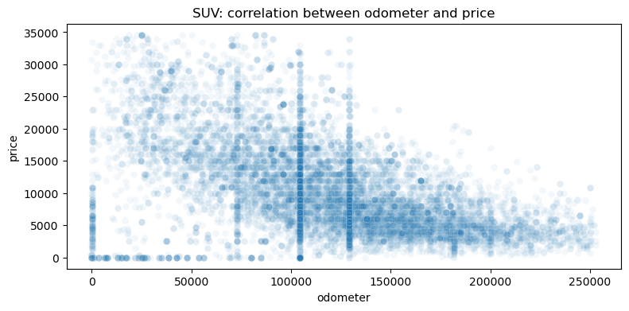

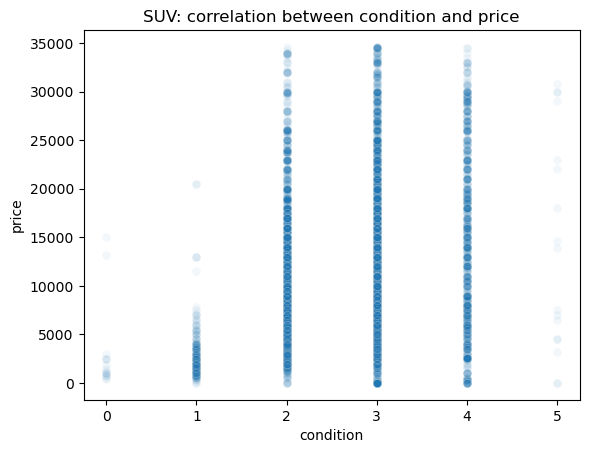

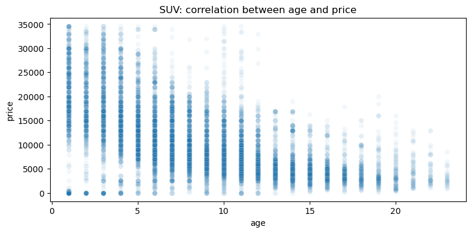

```
transmission
automatic    11210
manual         456
other          157
Name: count, dtype: int64
```

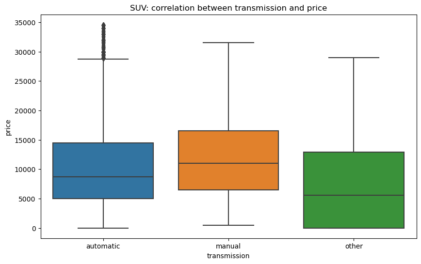

```
paint_color
unknown    2130
black      2080
white      1857
silver     1525
grey       1144
blue       1006
red         867
green       407
brown       350
custom      296
orange       81
yellow       43
purple       37
Name: count, dtype: int64
```

```
['unknown',
 'black',
 'white',
 'silver',
 'grey',
 'blue',
 'red',
 'green',
 'brown',
 'custom',
 'orange',
 'yellow',
 'purple']
```

|  | price | model_year | model | condition | cylinders | fuel | odometer | transmission | type | paint_color | is_4wd | date_posted | days_listed | day_name_posted | day_posted | month_posted | month_name_posted | year_posted | age | odometer_annual |
| --- | --- | --- | --- | --- | --- | --- | --- | --- | --- | --- | --- | --- | --- | --- | --- | --- | --- | --- | --- | --- |
| 0 | 9400 | 2011 | bmw x5 | 2 | 6 | gas | 145000.0 | automatic | SUV | unknown | True | 2018-06-23 | 19 | Saturday | 23 | 6 | June | 2018 | 7 | 20714.285714 |
| 1 | 15990 | 2013 | honda pilot | 3 | 6 | gas | 109473.0 | automatic | SUV | black | True | 2019-01-07 | 68 | Monday | 7 | 1 | January | 2019 | 6 | 18245.500000 |
| 2 | 11500 | 2012 | kia sorento | 3 | 4 | gas | 104174.0 | automatic | SUV | unknown | True | 2018-07-16 | 19 | Monday | 16 | 7 | July | 2018 | 6 | 17362.333333 |
| 3 | 9200 | 2008 | honda pilot | 3 | 6 | gas | 147191.0 | automatic | SUV | blue | True | 2019-02-15 | 17 | Friday | 15 | 2 | February | 2019 | 11 | 13381.000000 |
| 4 | 12990 | 2009 | gmc yukon | 3 | 8 | gas | 132285.0 | automatic | SUV | black | True | 2019-01-31 | 24 | Thursday | 31 | 1 | January | 2019 | 10 | 13228.500000 |
| ... | ... | ... | ... | ... | ... | ... | ... | ... | ... | ... | ... | ... | ... | ... | ... | ... | ... | ... | ... | ... |
| 11818 | 9500 | 2012 | chevrolet traverse | 2 | 6 | gas | 144500.0 | automatic | SUV | unknown | True | 2019-03-05 | 1 | Tuesday | 5 | 3 | March | 2019 | 7 | 20642.857143 |
| 11819 | 4999 | 2002 | toyota 4runner | 3 | 6 | gas | 177901.0 | automatic | SUV | unknown | True | 2018-05-26 | 59 | Saturday | 26 | 5 | May | 2018 | 16 | 11118.812500 |
| 11820 | 6995 | 2012 | buick enclave | 3 | 6 | gas | 157000.0 | automatic | SUV | white | True | 2018-08-04 | 17 | Saturday | 4 | 8 | August | 2018 | 6 | 26166.666667 |
| 11821 | 7995 | 2011 | chevrolet equinox | 4 | 4 | gas | 111088.0 | automatic | SUV | unknown | False | 2019-04-01 | 175 | Monday | 1 | 4 | April | 2019 | 8 | 13886.000000 |
| 11822 | 8999 | 2011 | jeep grand cherokee | 2 | 6 | gas | 129000.0 | automatic | SUV | white | True | 2018-11-01 | 51 | Thursday | 1 | 11 | November | 2018 | 7 | 18428.571429 |

11823 rows × 20 columns

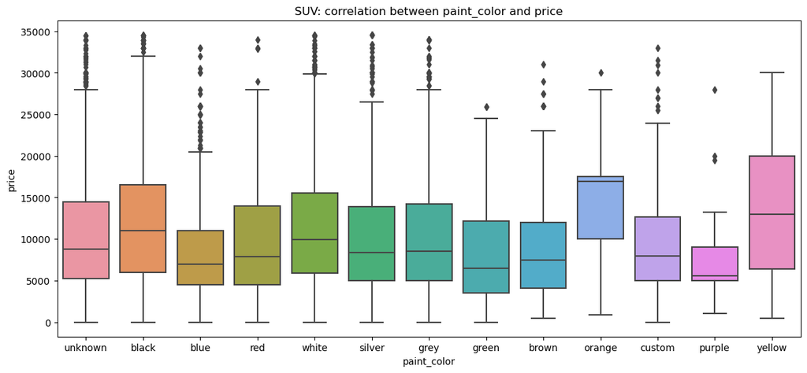

# Neural Network Model using TensorFlow and Keras to perform Regression

```
1031/1031 ━━━━━━━━━━━━━━━━━━━━ 6s 3ms/step - loss: 240452448.0000 - val_loss: 261087392.0000
1031/1031 ━━━━━━━━━━━━━━━━━━━━ 2s 2ms/step - loss: 235625664.0000 - val_loss: 254602928.0000
1031/1031 ━━━━━━━━━━━━━━━━━━━━ 3s 2ms/step - loss: 230759072.0000 - val_loss: 245441616.0000
1031/1031 ━━━━━━━━━━━━━━━━━━━━ 2s 2ms/step - loss: 217928320.0000 - val_loss: 234400048.0000
1031/1031 ━━━━━━━━━━━━━━━━━━━━ 2s 2ms/step - loss: 213479056.0000 - val_loss: 222018640.0000
1031/1031 ━━━━━━━━━━━━━━━━━━━━ 2s 2ms/step - loss: 196324480.0000 - val_loss: 208760304.0000
1031/1031 ━━━━━━━━━━━━━━━━━━━━ 2s 2ms/step - loss: 188881280.0000 - val_loss: 195089920.0000
1031/1031 ━━━━━━━━━━━━━━━━━━━━ 3s 2ms/step - loss: 171330672.0000 - val_loss: 181342848.0000
1031/1031 ━━━━━━━━━━━━━━━━━━━━ 3s 3ms/step - loss: 159265168.0000 - val_loss: 168038816.0000
1031/1031 ━━━━━━━━━━━━━━━━━━━━ 2s 2ms/step - loss: 142969648.0000 - val_loss: 155477584.0000
Train Loss: 139875136.0
Test Loss: 148059680.0
```

# Random Forest Regression

```
Number of trees (estimators) in Random Forest: 100
Train Loss (Random Forest Regression): 4853161.560541999
Test Loss (Random Forest Regression): 32926363.587604124
```

# Linear Regression

```
Train Loss (Linear Regression): 50733877.99016937
Test Loss (Linear Regression): 56897539.181750946
```

#### Training Loss:

This represents the error of the model on the training dataset. It is calculated as the difference between the actual target values and the predicted values of the model, typically using a loss function (e.g., mean squared error for regression problems). A lower training loss indicates that the model is fitting well to the training data.

#### Testing Loss:

This represents the error of the model on the testing dataset, which contains data that the model has not seen during training. It is calculated in the same way as the training loss. The testing loss provides an estimate of how well the model generalizes to new, unseen data. A similar (but not necessarily identical) testing loss compared to the training loss suggests that the model is not overfitting.

# Decision Tree Regression

```
Train Loss: 539748.4444241101
Test Loss: 84770266.99811314
```

# Gradient Boosting Regression

```
Train Loss: 40811233.93412305
Test Loss: 39573611.107459165
```